# Calculate Total number of steps taken per day

Load dplyr package and Read the file activity.csv.

```r
library(dplyr)
data <- read.csv("activity.csv", header=TRUE, stringsAsFactors=FALSE)
```

Prepare the data by using dplyr package. Do a group by on date.

```r
data$date <- as.Date(data$date)
grouped_date <- group_by(data, date)
```

## Calculate Total number of steps taken per day

Use summarize function in dplyr to add the steps for all the interval on a day.

```r
steps_per_day <- summarize(grouped_date, sum(steps, na.rm=TRUE))
names(steps_per_day) <- c("Date","TotalSteps")
```

Draw the histogram using base plot system.

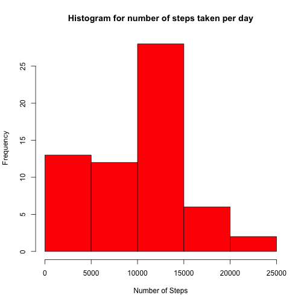

```r
hist(steps_per_day$TotalSteps, xlab="Number of Steps", main="Histogram for number of steps taken per day", col="red")
```

Mean of total number of steps taken per day:

```r
mean(steps_per_day$TotalSteps)
```

```
## [1] 9354.23
```

Median of total number of steps taken per day:

```r
median(steps_per_day$TotalSteps)
```

```
## [1] 10395
```

## Average daily activity pattern

Calculating steps per interval across all days using dplyr package.

```r
grouped_interval <- group_by(data,interval)
steps_per_interval <- summarize(grouped_interval,mean(steps, na.rm=TRUE))
names(steps_per_interval) <- c("Interval", "Steps")
```

Time series plot of the 5-minute interval (x-axis) and the average number of steps taken, averaged across all days (y-axis)

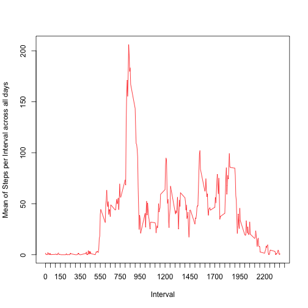

```r
plot(steps_per_interval$Interval,steps_per_interval$Steps, type="l", col="red" , xlab="Interval" , ylab="Mean of Steps per Interval across all days", xaxt="n")
axis(side=1,at=seq(from=0, to=2400, by=50))
```

The 5-minute interval, on average across all the days that contains the maximum number of steps is

```r
steps_per_interval$Interval[which.max(steps_per_interval$Steps)]
```

```
## [1] 835
```

## Imputing missing values

Total number of missing values in the dataset

```r
sum(is.na(data$steps))
```

```
## [1] 2304
```

Use mean for the 5-minute interval to fill in NA values. The new dataset is data_witout_NA

```r
data_witout_NA <- data
for(x in 1:length(data_witout_NA$steps)) {
   if(is.na(data_witout_NA$steps[x])) {
    interval <- data_witout_NA$interval[x]
    index <- which(steps_per_interval$Interval== interval, TRUE)
    data_witout_NA$steps[x] <- round(steps_per_interval$Steps[index])
  }
}
```

Histogram of the total number of steps after filling in missing values.

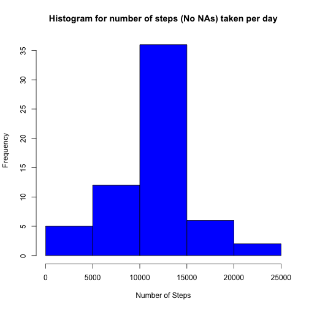

```r
grouped_date_withoutNA <- group_by(data_witout_NA, date)
steps_per_day_withoutNA <- summarize(grouped_date_withoutNA, sum(steps))
names(steps_per_day_withoutNA) <- c("Date","TotalSteps")
hist(steps_per_day_withoutNA$TotalSteps, xlab="Number of Steps", main="Histogram for number of steps (No NAs) taken per day", col="blue")
```

Mean of total number of steps taken per day.

```r
mean(steps_per_day_withoutNA$TotalSteps)
```

```
## [1] 10765.64
```

Median of total number of steps taken per day

```r
median(steps_per_day_withoutNA$TotalSteps)
```

```
## [1] 10762
```

## Activity patterns between weekdays and weekends

Add the dayType variable to dataset. The value can be Weekend or Weekday.

```r
for(x in 1:length(data_witout_NA$steps)) {
    dayType <- weekdays(data_witout_NA$date[x])
    if(dayType == "Saturday" || dayType == "Sunday") {
      data_witout_NA$dayType[x] <- "Weekend"
    } else {
      data_witout_NA$dayType[x] <- "Weekday"
    }

}
```

Do a group by on dayType and Interval.

```r
grouped_week <- group_by(data_witout_NA, dayType, interval)
week_data <- summarize(grouped_week,round(mean(steps)))
names(week_data) <- c("dayType","interval", "steps")
```

Panel containing a time series plot of the 5-minute interval (x-axis) and the average number of steps taken, averaged across all weekday days or weekend days (y-axis) using lattice plot system.

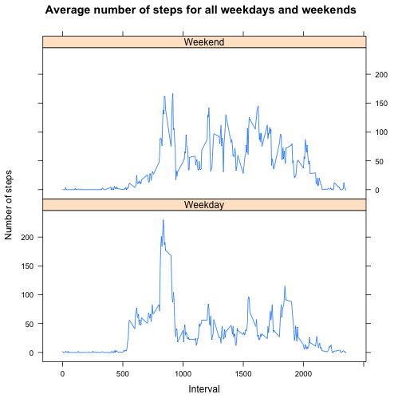

```r
library(lattice)
xyplot(steps ~ interval | dayType, data = week_data, layout = c(1, 2), ylab = "Number of steps",
    main = "Average number of steps for all weekdays and weekends" ,xlab = "Interval", type="l" )
```